# Getting Started in ggplot2

ggplot2 is one of the most commonly used data visualization packages in R. It is based on *The Grammar of Graphics* by Leland Wilkinson and his idea that all graphs contain some combination of the following elements:

- Data
- Geometric objects (called **geoms**)
- Statistical transformations (called **stats**)
- Scales
- A coordinate system (called **coord**)

## Setup

Data: [Land Values by State](http://guides.lib.unc.edu/ld.php?content_id=37152836)

```r
#Load your libraries.
library(ggplot2)
library(dplyr)

#Load the csv file into a data frame object.
states <- read.csv("landdata-states.csv")
```

## Geoms and Aesthetics

There are 33 different types of geometric objects, or geoms, that can be added to a chart in ggplot. They include bars, lines, points, etc. A chart can contain *multiple* geoms that are layered on top of each other.

Aesthetics are used by calling the **aes()** function. They determine how visual characteristics within the plot represent your data, including which variables are plotted on which axes. Each geom, as well as the entire chart itself can be given aesthetics.

## Basic Charts

Lets start with a simple bar chart. Our dataset contains information about states and which region of the country they fall into. How many records do we have for each region?

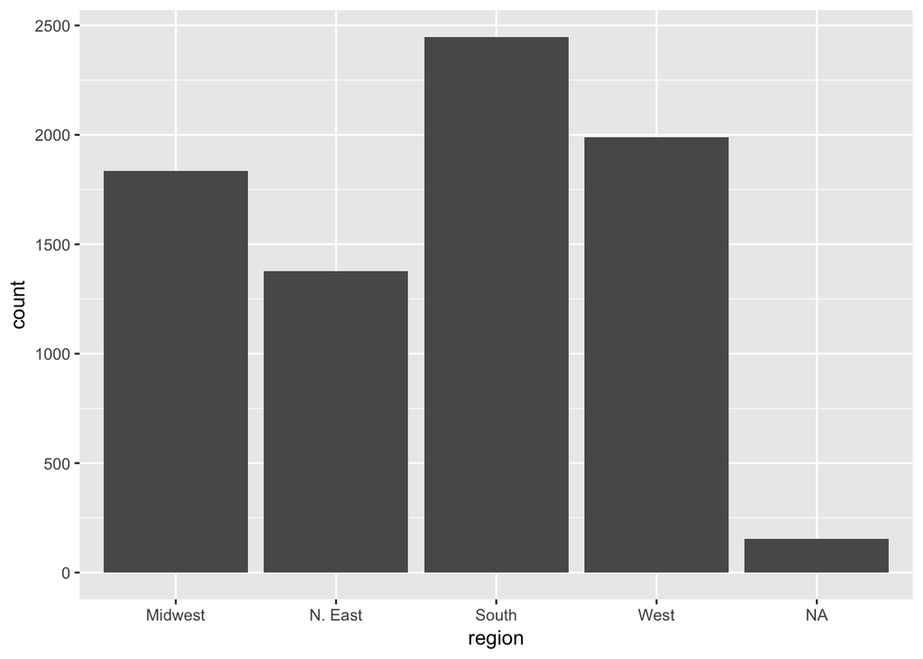

```r
ggplot(data = states, aes(x = region)) +
  geom_bar()
```

Notice that we’ve used the **aes()** function to plot the region variable on the x axis. Also, our bar geom is added using the “+” sign on the line before.

Now, let’s try a line chart. We want to look at the land values of North Carolina over time, but first we need to filter our data so that we are focusing on North Carolina. We’ll do that using dplyr.

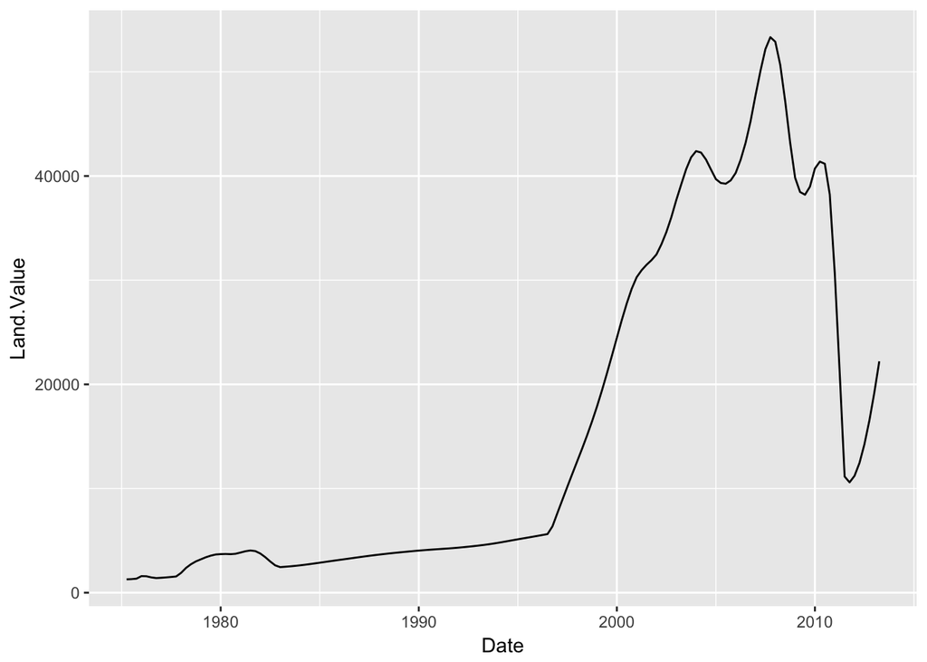

```r
#Filter data to only include North Carolina
statesNC <- filter(states, State == 'NC')

#Line chart of NC land value over time
ggplot(data = statesNC, aes(x = Date, y = Land.Value)) +
  geom_line()
```

How about a scatterplot comparing home values to land values? This time we’ll include data for all states but only from the first quarter of 1986.

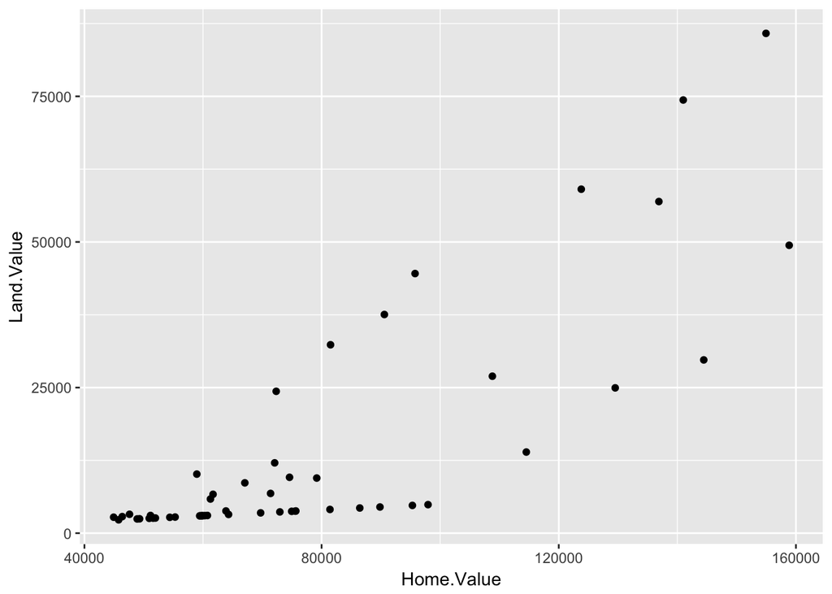

```r
#Filter data to only include first quarter of 1986
states1q1986 <- filter(states, Date == 1986.25)

#Scatterplot of home values by land values for first quarter of 1986
ggplot(data = states1q1986, aes(x = Home.Value, y = Land.Value)) +
  geom_point()
```

Remember, you can add multiple geoms on top of one another. Let’s draw a line that connects those points.

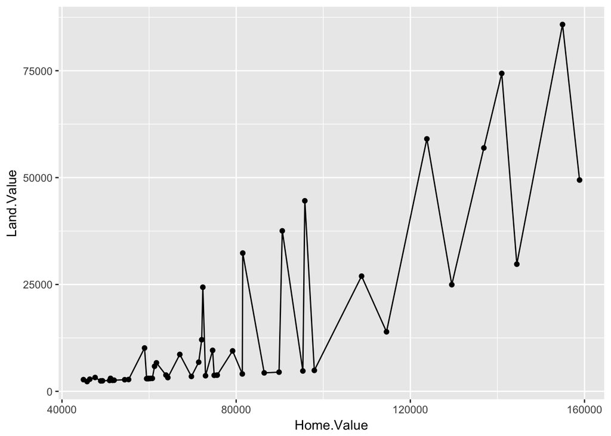

```r
ggplot(data = states1q1986, aes(x = Home.Value, y = Land.Value)) +
  geom_point() +
  geom_line()
```

Now we want to create multiple lines for each region, and each line needs to have its own color. We use the **aes()** function on *each geom* to do this.

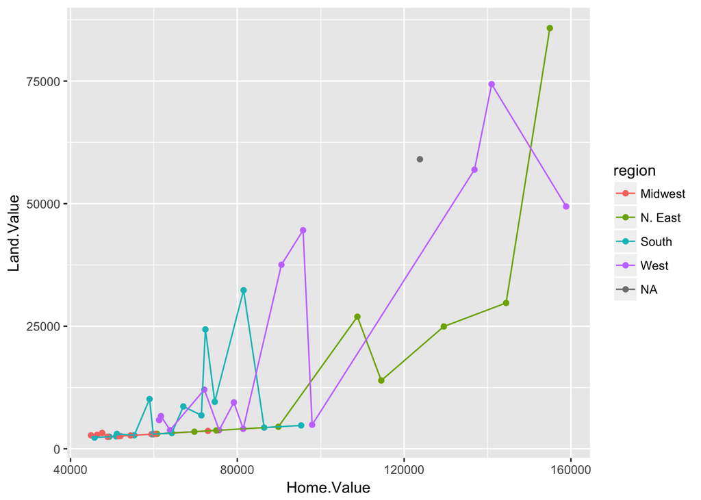

```r
ggplot(data = states1q1986, aes(x = Home.Value, y = Land.Value)) +
  geom_point(aes(color = region)) +
  geom_line(aes(color = region))
```

Instead of color, we could also use symbols and different types of lines.

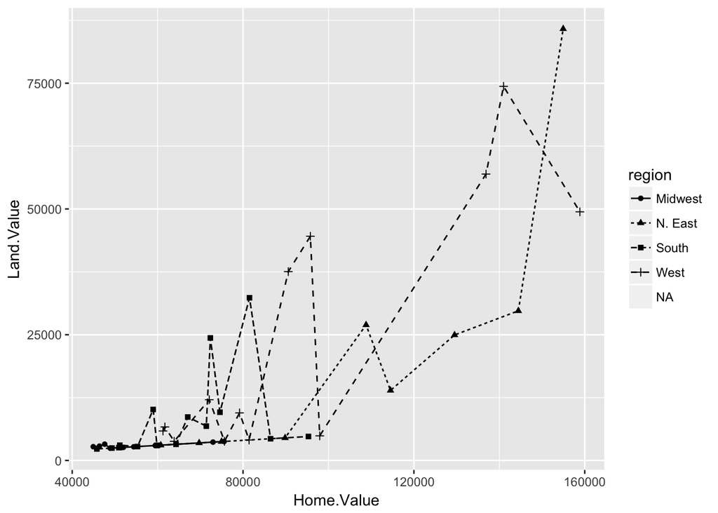

```r
ggplot(data = states1q1986, aes(x = Home.Value, y = Land.Value)) +
  geom_point(aes(shape = region)) +
  geom_line(aes(linetype = region))
```

A linear regression line would probably be more useful than just connecting the dots. The **smooth** geom lets us add one in.

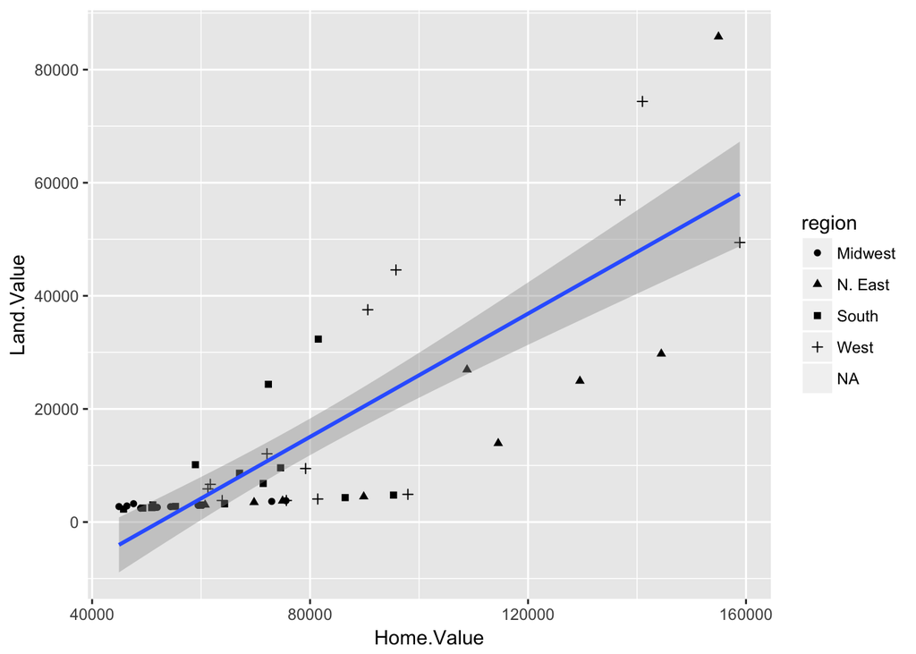

```r
ggplot(data = states1q1986, aes(x = Home.Value, y = Land.Value)) +
  geom_point(aes(shape = region)) +
  geom_smooth(method = lm)
```

## Adding Stats

stats are statistical transformations of the data within a chart. The following graph shows the average Home Price Indexes for all regions over all time periods in the dataset.

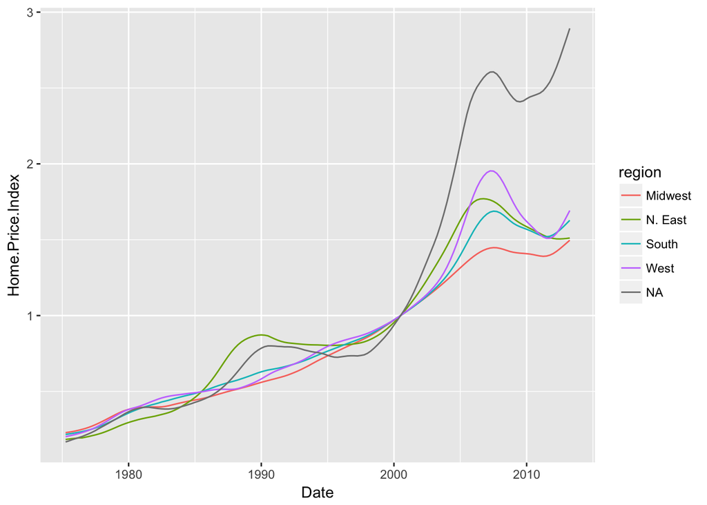

```r
ggplot(data = states, aes(x = Date, y = Home.Price.Index)) +
  geom_line(stat = 'summary', fun.y = 'mean', aes(color = region))
```

Every geom has a default stat. You can modify which stat it uses. For example, the default stat for geom_bar is “count”. If we want to use another variable besides the total number of records (the “count”) on our y axis, we need to use the stat “identity”.

Let’s say we want a bar chart of home price indexes on Southern states in the first quarter of 2010.

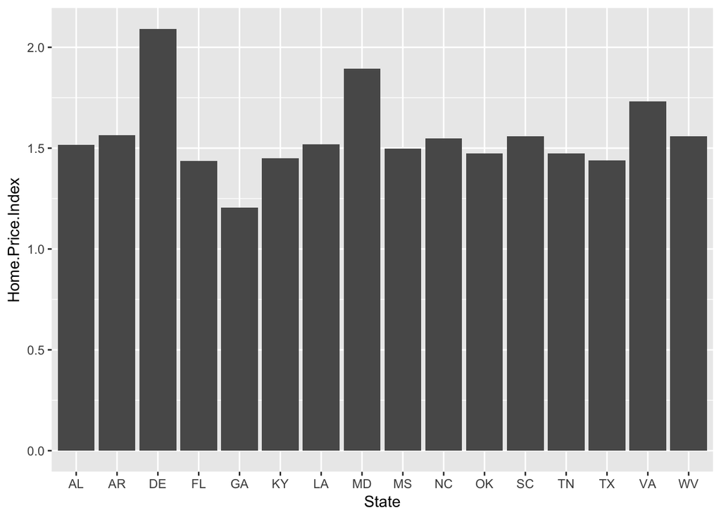

```r
#Filter the data for only the southern region and first quarter of 2010.
states1q2010South = filter(states, region == 'South', Date == 2010.25)

#The default stat for geom_bar is "count". Use "identity" to plot different variables on the y axis.
ggplot(data = states1q2010South, aes(x = State, y = Home.Price.Index)) +
  geom_bar(stat = 'identity')
```

## Scales

Below is a bubble chart that uses both size and color aesthetics.

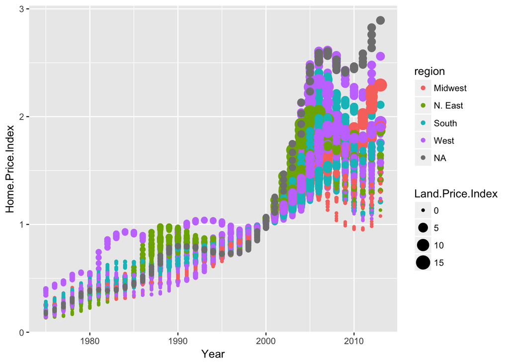

```r
ggplot(data = states, aes(x = Year, y = Home.Price.Index)) +
  geom_point(aes(color = region, size = Land.Price.Index))
```

Add scale layers to fine-tune the size and color scales.

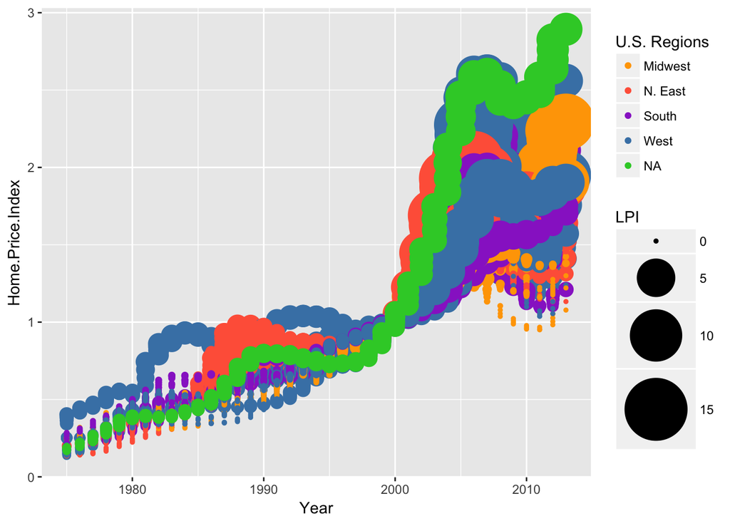

```r
ggplot(data = states, aes(x = Year, y = Home.Price.Index)) +
  geom_point(aes(color = region, size =  Land.Price.Index)) +
  scale_color_manual(name = 'U.S. Regions',
                     values = c(Midwest='orange', `N. East`='tomato', South='darkorchid', West='steelblue'),
                     na.value = 'limegreen') +
  scale_size_continuous(name = 'LPI', range = c(1,20))
```

## Coordinates

Remember the bar chart we made earlier with the identity stat? We can use a coord layer to make it horizontal!

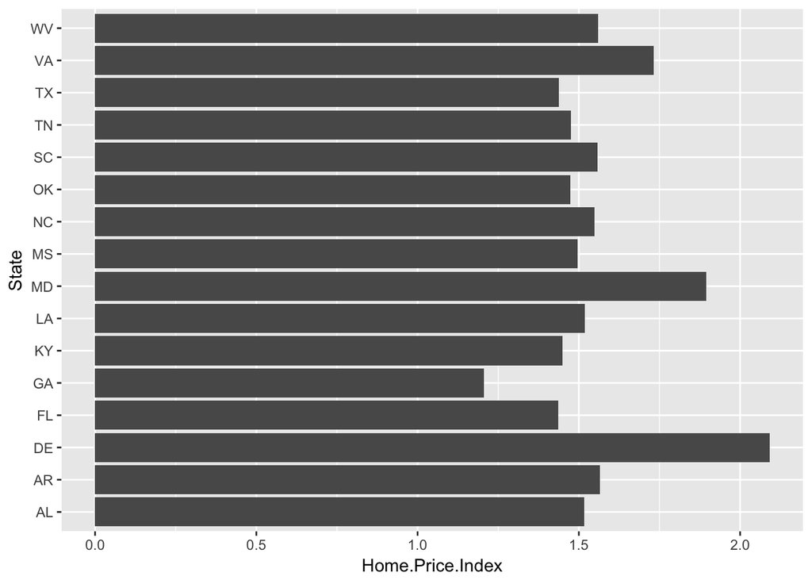

```r
ggplot(data = states1q2010South, aes(x = State, y = Home.Price.Index)) +
  geom_bar(stat = 'identity') +
  coord_flip()
```

## Facets

This line plot we made earlier can be hard to read.

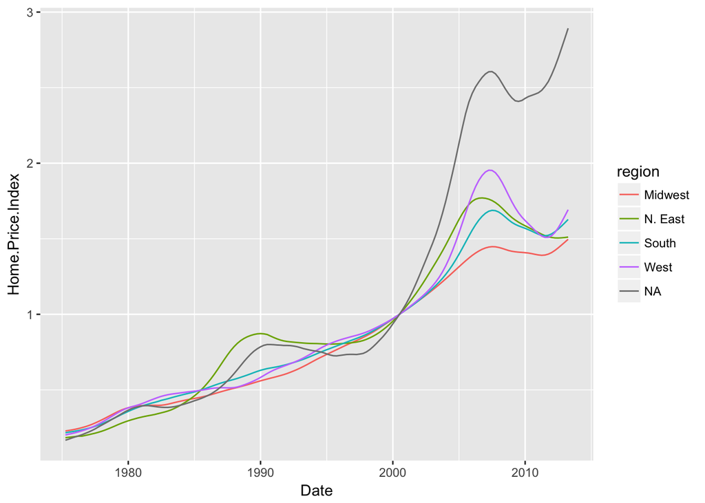

```r
ggplot(data = states, aes(x = Date, y = Home.Price.Index)) +
  geom_line(stat = 'summary', fun.y = 'mean', aes(color = region))
```

Using a different plot for each region makes the lines easier to see.

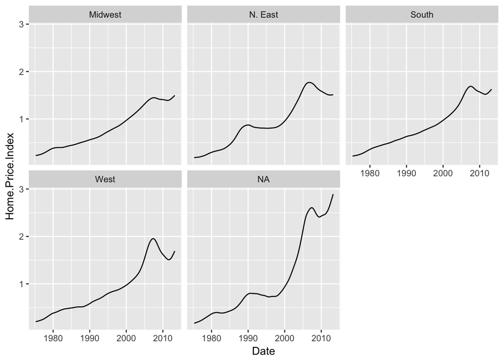

```r
ggplot(data = states, aes(x = Date, y = Home.Price.Index)) +
  geom_line(stat = 'summary', fun.y = 'mean') +
  facet_wrap(~region)
```

## Exercises and Tutorials

- [A comprehensive tutorial that addresses more features in ggplot](http://r-statistics.co/Complete-Ggplot2-Tutorial-Part1-With-R-Code.html)
- [Exercises for visualizing categorical variables](https://www.r-exercises.com/2016/12/11/descriptive-analytics-part-5-data-visualisation-categorical-variables/)
- [Exercises for visualizing continuous variables](https://www.r-exercises.com/2016/12/04/descriptive-analytics-part-5-data-visualisation-continuous-variables/)
- [Cheat sheet for ggplot2](https://www.rstudio.com/wp-content/uploads/2015/03/ggplot2-cheatsheet.pdf)